# 4. The Ames Housing Data

Russ Conte

2022-05-25

Start by loading the required packages in two lines of code:

```r
Packages <- c("tidymodels", "caret", "broom", "sf")
lapply(Packages, library, character = TRUE)
```

```
## • Use suppressPackageStartupMessages() to eliminate package startup messages
```

[output not shown]

Start with code for multi-core processing

```r
library(doParallel)
cl <- makePSOCKcluster(10)
registerDoParallel(cl)
```

The data set contains information on 2930 properties in Ames, Iowa including columns related to:

- House characteristics (bedrooms, garage, fireplace, pool, porch, etc.)
- Location (neighborhood)
- Lot information (zoning, shape, size, etc.)
- Ratings of condition and quality
- Sale price

Are modeling goal is to predict the sale price of a house based on other information we have such as his characteristics and location.

For this analysis, we will use a transformed version of the data available in the **modeldata** package. Note that **modeldata** is loaded with the tidymodels package.

Some columns were modified from the original data. For example:

- In the raw data, if a house did not have a particular feature (such as a garage) it was implicity encoded as missing. For example, 2,732 properties did not have an alleyway. Instead of leaving these as missing, they were relabeled in the transformed version to indicate that no alley was available.
- The categorical predictors were converted to R’s factor data type. While both the tidyverse and base R have moved away from importing data as factors by default, this data type is a better approach for storing qualitative data for modeling than simple strings.
- We removed a set of quality descriptors for each property since they are more like outcomes than predictors.

To load the data:

```r
data(ames)

dim(ames)
```

```
## [1] 2930   74
```

Let’s start our exploratory data analysis by focusing on the outcome we want to predict: The last sale price on the house (in $USD). We can create a histogram to see the distribution of sale prices in Figure 4.1:

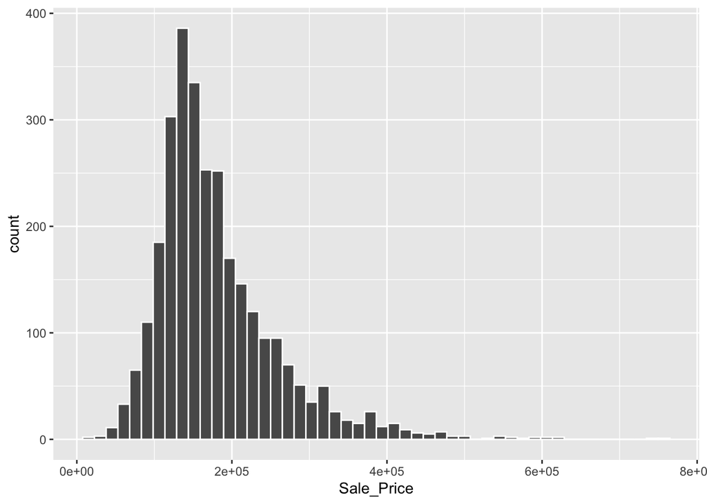

```r
tidymodels_prefer()

ggplot(ames, aes(x = Sale_Price)) +
  geom_histogram(bins = 50, col = "white")
```

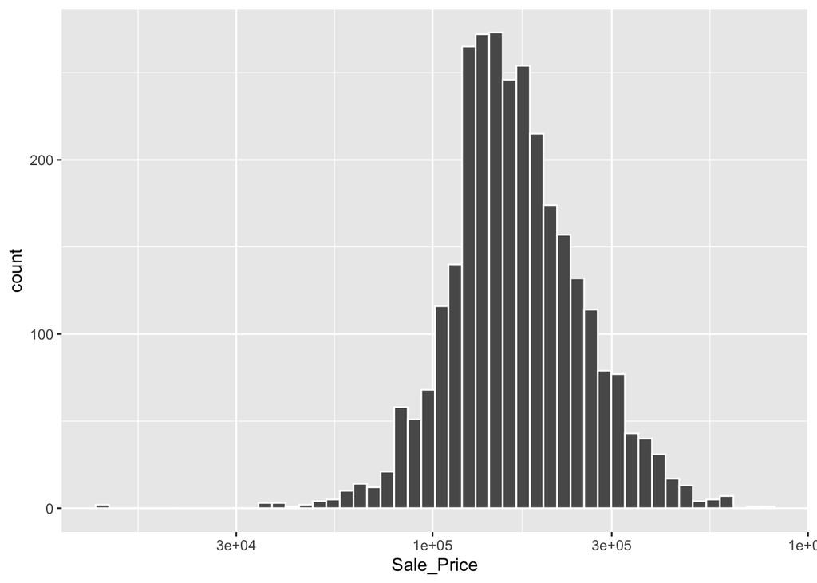

```r
ggplot(ames, aes(x = Sale_Price)) +
  geom_histogram(bins = 50, col = "white") +
  scale_x_log10()
```

The models of the aims housing data used in this book used a log transformation for this outcome.*From this point on*, the outcome column is pre-logged in the `ames` data frame:

```r
ames <- ames %>% mutate(Sale_Price = log10(Sale_Price))
```

## 4.2 ChapterSummary

This chapter introduced the Ames housing data set and investigated some of its characteristics. This data set will be used in later chapters to demonstrate tidymodels syntax. Exploratory data analysis like this is in an essential component of any modeling project; EDA uncovers information that contributes to better modeling practice.

The important code for preparing the AIM status said that we will carry forward into subsequent chapters is:

```r
library(tidymodels)
data(ames)
ames <- ames %>% mutate(Sale_Price = log10(Sale_Price))
```

REFERENCES

De Cock, D. 2011. “Ames, Iowa: Alternative to the Boston Housing Data as an End of Semester Regression Project.” Journal of Statistics Education 19 (3).